# Impact of AmeriCorps on RI Communities

Published: June 2024

##### Return to Reports Page

AmeriCorps offers pathways to success for both service recipients and service volunteers in Rhode Island. Working mainly in economically disadvantaged urban neighborhoods, AmeriCorps members provide vital services for those in need. AmeriCorps members who come from these same neighborhoods gain education and employment opportunities they may not otherwise have had.

Through Segal Education Awards and extensive training, AmeriCorps leverages federal funding to help thousands of Rhode Island AmeriCorps members complete college, enter the workforce, and contribute to the local economy. These members also benefit the state by putting their skills to work in the social sector and remaining civically engaged.

### The Value of Service in Rhode Island:

AmeriCorps, a federal program designed to meet critical needs in areas such as education, the environment, and public safety, makes an outsized impact on Rhode Island. As of 2019, Rhode Island ranks 7th among the states for per capita AmeriCorps participation, and Providence ranks 2nd in the nation among small cities[^1]. Since the state’s program began in 1994, more than 8,500 Rhode Island residents have served approximately 12 million hours in Rhode Island communities and have earned education awards totaling more than $30.4 million[^2].

Why concentrate on AmeriCorps members in Rhode Island? Although any form of service is valuable, national service programs like AmeriCorps offer several features that set them apart:

- They leverage federal funding to address issues facing local neighborhoods.
- They offer training and structure to build skills and help ensure effectiveness of programs.
- In addition to a living allowance, AmeriCorps offers student loan deferment and a post-service Segal Education Award, which members can apply toward higher education costs or toward repaying qualified federal student loans.
- AmeriCorps offers programs requiring varying levels of service, but all require at least 300 hours within a 12-month term, with full-time members serving 1,700+ hours during their term. This is important because volunteers who serve for at least 300 hours (termed high-intensity volunteers) are more likely to provide value and to reap the benefits of service.

AmeriCorps awards federal funds to the Rhode Island Department of Education to administer local programs approved and supported by ServeRI, the Rhode Island Commission for National and Community Service.

This report focuses on a key group that has not only provided a huge benefit to Rhode Island communities through their service but who are positioned to make an ongoing impact in the state. The cohort includes the 506 AmeriCorps members who:

- Served in Rhode Island within the past 5 years.
- Were born in 1985 or later.
- Have served at least 300 hours in one year (high-intensity volunteers).

### AmeriCorps Service Provides Pathways to Higher Education and Careers:

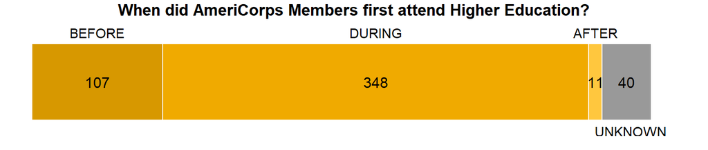

**Figure 1:** Cohort postsecondary enrollment timeline

Of the 506 individuals in this cohort, 466 were found in RILDS’ higher education data holdings. As Figure 1 illustrates, the majority of this cohort of AmeriCorps members first attended college during or between their AmeriCorps terms (when serving multiple terms). This finding defies the common notion of AmeriCorps members as solely those taking a “gap year” before starting college. It also aligns with the finding that most of the members in our group, including those from in-state and out-of-state, stayed in Rhode Island for college. Of the members from this cohort who were matched in the RILDS database, 66% attended a public institution and 79% attended a 4-year institution.

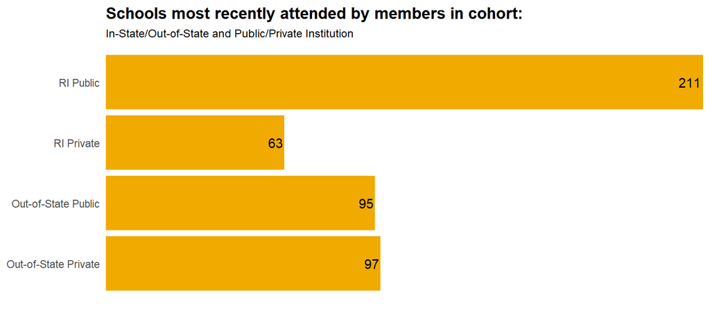

**Figure 2:** Cohort postesecondary enrollment outcomes

The cohort’s most recent higher education enrollment reveals that Rhode Island is reaping the benefit of AmeriCorps members who remain in state to further their education. Among schools attended, seven of the top ten are in Rhode Island, and the top three are all public institutions. A side benefit is that these members are likely using the Education Award that comes with AmeriCorps service at these institutions- over $12 million has been paid to RI from 1994 to 2020[^3].

AmeriCorps members tend to remain in Rhode Island not only for school but also for work. Figure 3 shows 2022 workforce participation among AmeriCorps alumni (those who have completed their terms of service). Up to three years post-service, the majority of the cohort are working in the state, contributing to a net “brain gain,” with well-qualified employees from both in-state and out-of-state contributing to the Rhode Island workforce post-service. Roughly one out of two members remain in the Rhode Island workforce four years after serving.

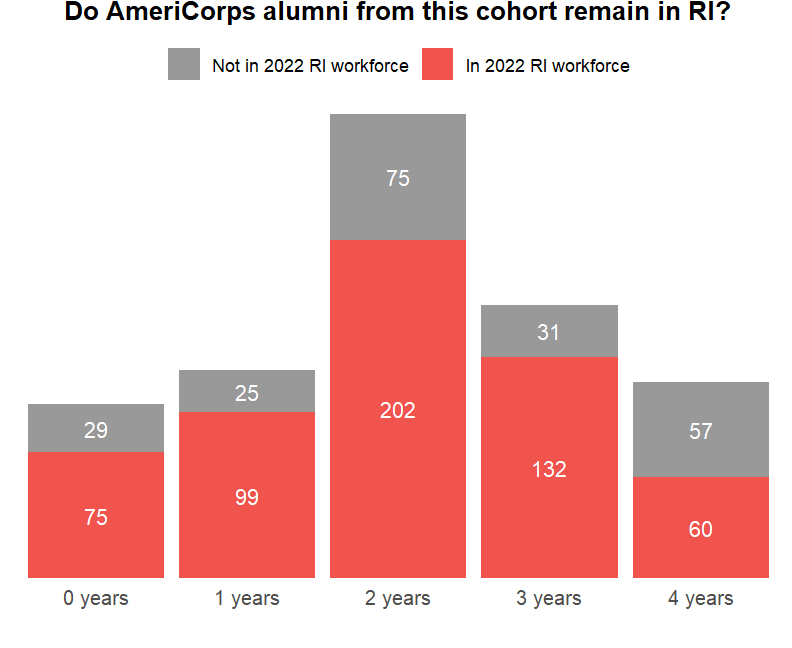

**Figure 3:** Cohort alumni by 2022 RI workforce participation and years since last service term

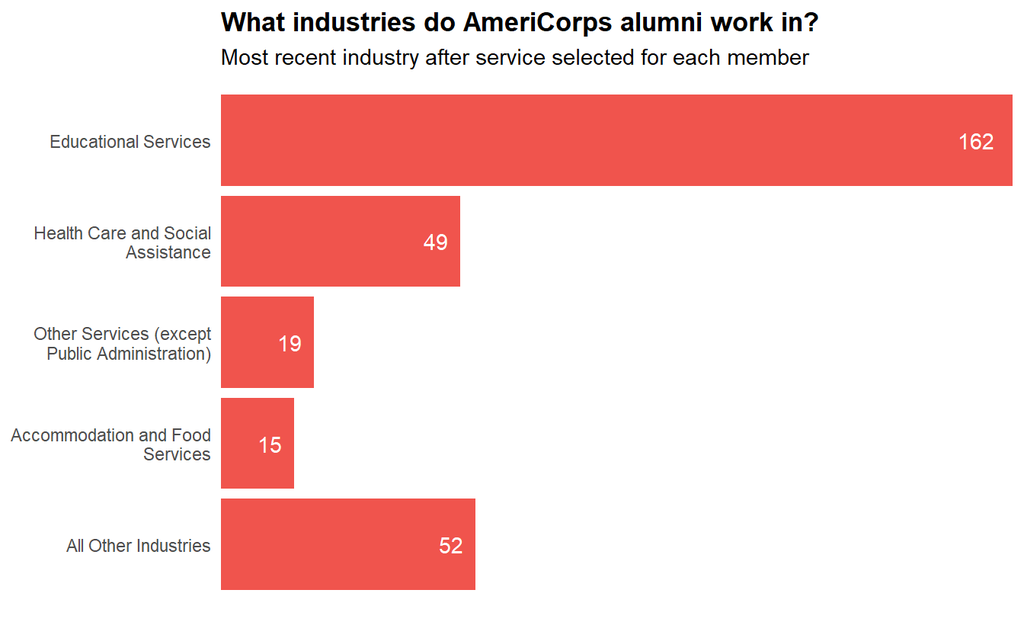

**Figure 4:** Most common industries of employment of AmeriCorps cohort

Employment data also demonstrate this group’s ability to contribute to the state’s overall economic and social vitality. Health care and education are both important economic drivers, offering relatively high wages, employment stability, and projected job growth.

Tellingly, these industries also correlate with AmeriCorps service areas; those who serve develop not only the desire to work in the social sector but also the skills and experience to do so. AmeriCorps thus provides a form of demand-driven workforce development, where local need drives skill development, which is then deployed in the Rhode Island workforce.

Figure 5 shows this cohort’s inflation-adjusted median annual wage by age compared to that of a comparison cohort. The comparison cohort was limited to individuals who were born between 1985 and 2004 and who were enrolled in any Rhode Island high school that was attended by members of the AmeriCorps cohort. On average, AmeriCorps members are set on a path to exceed RI living wage by age 24. As shown in Figure 5, this AmeriCorps cohort consistently outearns their comparison cohort starting at age 23.

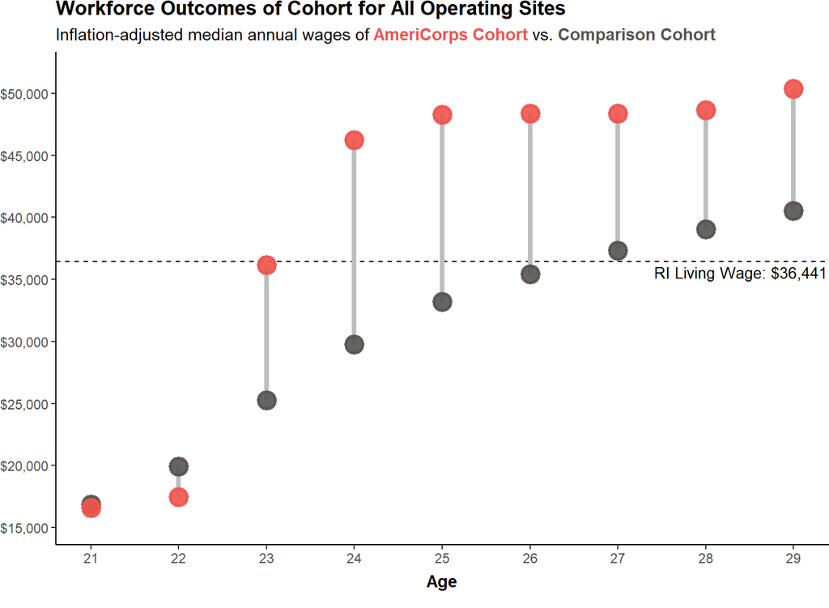

**Figure 5:** Wage outcomes of AmeriCorps cohort

### Members come from the Communities they Serve:

This report focused on a key group that has not only provided a huge benefit to Rhode Island communities through their service but who are positioned to make an ongoing impact in the state. Our cohort includes the 506 AmeriCorps members who:

- Served in Rhode Island within the past 5 years.
- Were born in 1985 or later.
- Have served at least 300 hours in one year (high-intensity volunteers).

Figures 6 through 8 show the demographic breakdown of this cohort, focusing on race/ethnicity, gender, and age. Of the 506 members in this cohort, 47% identify as White, 23% identify as Hispanic, 12% identify as Black or African American, and 8% identify as Asian or Asian American. Note that based on the format of the data used to develop this analysis, race and ethnicity were combined into a single demographic variable and individuals in this cohort may be represented in multiple categories. Comparing this to the entire population of RI, the U.S. Census Bureau estimated the distribution of race in RI in 2022 was 83% White, 9% Black or African American, and 4% Asian. The U.S. Census Bureau collects race and ethnicity as two separate demographic variables, therefore the estimate of the ethnicity of the 2022 RI population was reported separately as 18% Hispanic or Latino.

Roughly two out of three members of the cohort identify as female; this percentage is about the same as the U.S. Bureau of Labor Statistics’ 2022 estimate of the private nonprofit workforce, which was 66% female. Lastly, two out of three members of the cohort were between 20-24 years old at the start of their AmeriCorps service.

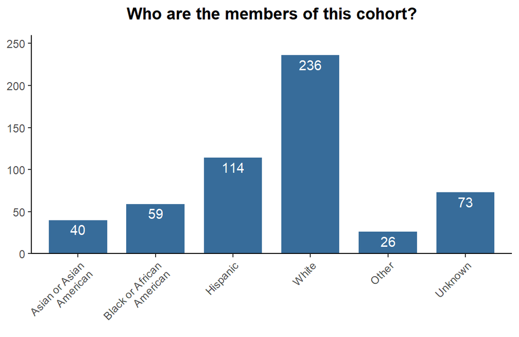

**Figure 6:** Cohort demographics by race

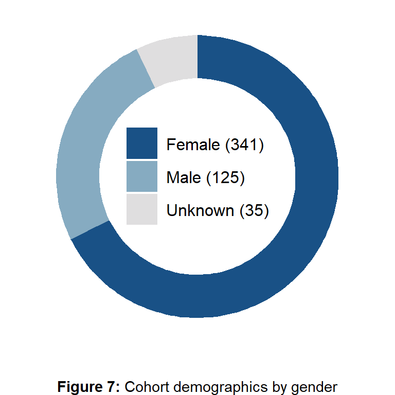

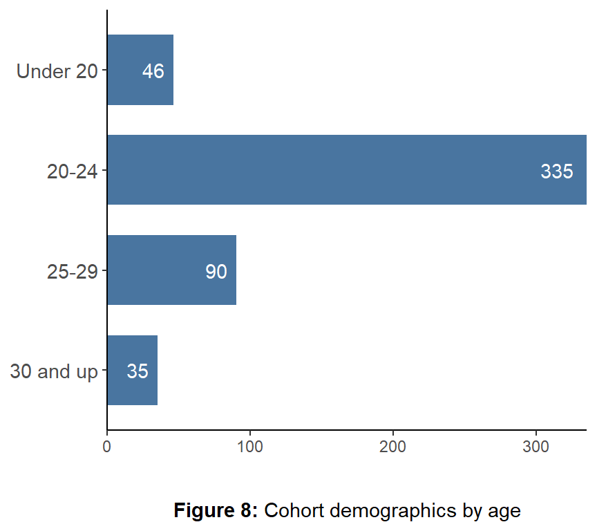

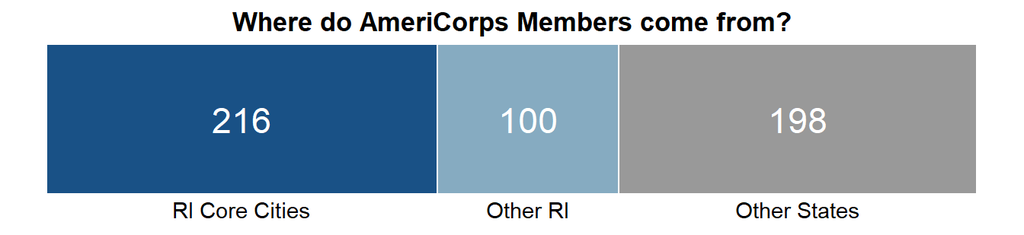

**Figure 9:** Cohort place of origin

By recruiting from these neighborhoods, AmeriCorps engages members who are uniquely qualified to address local issues. Far from the concern that only privileged individuals disconnected from these communities can afford to serve, these volunteers are the very people most likely to benefit from the training and funding AmeriCorps provides.

With poverty in Rhode Island at 10.8%[^4] and unemployment at 3.2% as of December 2023[^5], the need for volunteer services in Rhode Island is indisputable. Need varies widely by neighborhood, though.

#### **Do AmeriCorps members focus on areas of greatest need?**

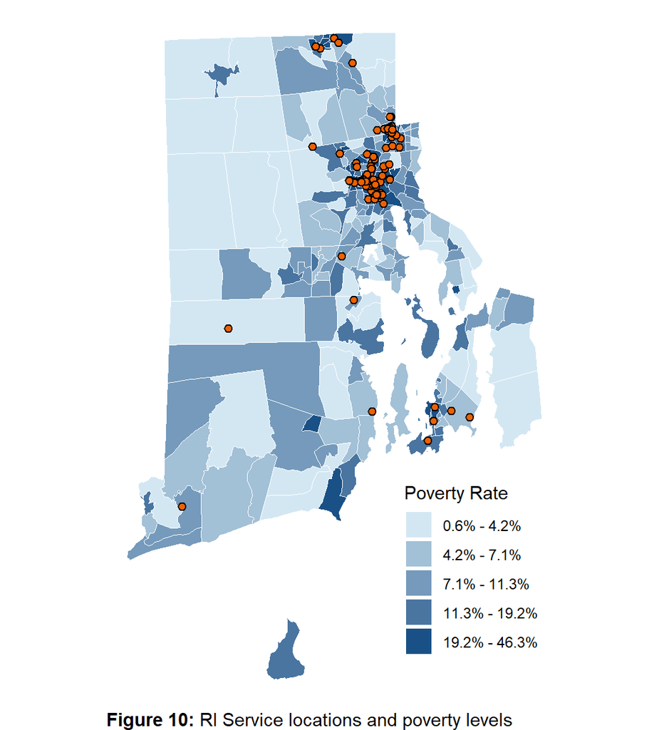

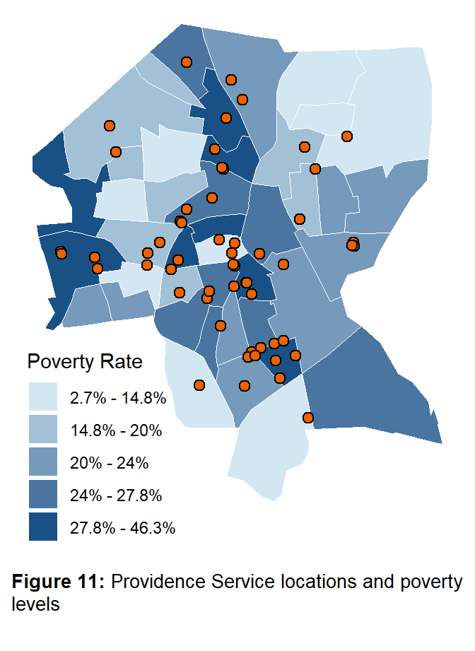

Figure 10 shows the locations of AmeriCorps service programs across the state of Rhode Island, while Figure 11 focuses on the locations in Providence. Service is concentrated in urban neighborhoods with the highest poverty rates, particularly in Providence and Central Falls, two areas with the highest concentration of poverty. It is clear from these maps that the AmeriCorps members in Rhode Island are focusing on areas with the greatest need.

AmeriCorps programs similarly focus on services that will have the greatest impact. Children are among those hardest hit by poverty; 12% of Rhode Islanders under age 18 live under the federal poverty level[^6], with those in Providence and other urban areas seeing rates near or above 30%[^7]. The majority of Rhode Island AmeriCorps programs focus on early childhood education, K-12 academic success, and college access services to help children get the education they need to secure good jobs and build wealth.

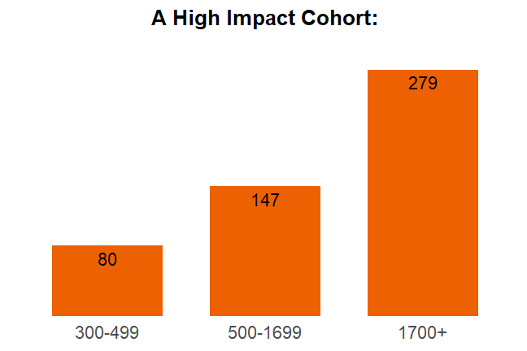

**Figure 12:** Cohort by number of hours served

In helping these communities in need, many of the AmeriCorps members in this cohort served more than 1,000 hours each in Rhode Island neighborhoods. Nearly half of them (48%) served two or more terms in RI. Figure 12 shows a breakdown of the cohort’s hours served, which considers each member’s cumulative hours.

A vast majority of this cohort, about nine out of ten members, served at a location that falls under the focus area umbrella of education. The next two most common focus areas for this cohort are Environmental Stewardship and Economic Opportunity, which account for roughly one out of ten members. Healthy Futures and Veterans & Military Families round out the list, but the number of members were suppressed for disclosure avoidance.

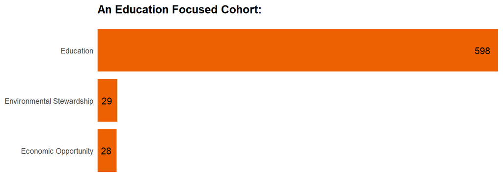

**Figure 13:** Cohort by service focus area (focus areas with counts under 10 are suppressed)

### Getting the Most from AmeriCorps:

With Rhode Island, and particularly Providence, ranking among the most active AmeriCorps programs in the nation, the state is well positioned to take advantage of the benefits this federally funded program offers. The high-intensity volunteers who serve through AmeriCorps provide valuable services in neighborhoods that are most in need. They also contribute to the state’s long-term economic and civic health by remaining in state for college and careers and by acting as engaged members of the community.

One compelling finding from this story is that AmeriCorps benefits its members in much the same way that it benefits the community members it serves. In recent years, hundreds of young volunteers from economically and academically disadvantaged backgrounds have gained resources, training, and motivation to succeed in school and become productive members of the workforce.

Following are actions various stakeholders can take to help ensure that RI reaps the full value that AmeriCorps can bring to the state’s communities:

- K-12 leaders can inform students of available AmeriCorps programs and encourage them to participate.
- Higher education leaders in the state can match the Segal Education Award to help make in-state education affordable for dedicated students. For more information, including the benefits of enrolling service alumni and a list of organizations that have made this commitment, see the federal Schools of National Service[^8] initiative.
- Employers can make national service participation a preferential criterion for employment. This benefits employers as well as job candidates who have served, since service provides valuable experience in areas of demonstrated need. For more information, including the benefits of employing national service alumni and a list of organizations that have made this commitment, see the federal Employers of National Service initiative[^9].
- Nonprofits, municipalities, faith-based organizations, and higher education institutions can apply for federal grants to host AmeriCorps teams. Grants help fund recruitment and training of AmeriCorps members working in education, disaster services, health, environmental stewardship, economic opportunity, and service to veterans and military families.
- Individuals can apply to become an AmeriCorps member in one of a variety of programs. AmeriCorps service offers members an opportunity to put their skills to work helping communities while earning money for education and acquiring essential job skills.

For additional information or assistance with these actions, contact serveri@ride.ri.gov or visit www.americorpsri.com.

#### About this Report:

This report was developed by the Rhode Island Longitudinal Data System (RILDS) Center. The report is based on data stored in RILDS as of April 2024.

Additional information regarding the data sets used in this report:

- Rhode Island Department of Education (RIDE) - K12 Enrollment Data
  - Records covering terms Fall 2004 through Spring 2022.
  - Data set limitation: Only students who attend the Rhode Island public school system are included in this data.
- AmeriCorps/ServeRI via RIDE - ServeRI Program Participation Data
  - Records covering dates September 1, 2010 through September 1, 2022.
- Office of the Postsecondary Commissioner (OPC) – Postsecondary Enrollment and Completions Data
  - Records covering terms Spring 2007 through Fall 2023.
  - Data set limitation: Only students who attend one of the three RI public institutions are included in this data.
- National Student Clearinghouse (NSC) via RIDE and OPC - Postsecondary Enrollment and Completions Data
  - Records covering terms Spring 2010 through Fall 2023.
- Department of Labor and Training (DLT) – Employment & Wage Data
  - Records covering quarters Q1 2011 through Q4 2022.
  - Data set limitation: Only employees of employers that pay into RI unemployment insurance are included in this data.
- U.S. Census Bureau – American Community Survey (ACS) Poverty Data (table C17002)
  - Records covering calendar year 2022.

All aggregated values below ten (10) were suppressed for this report.

##### Return to Reports Page

[^1]: [AmeriCorps Newsroom; Top 10 States, Cities Rankings](https://americorps.gov/newsroom/press-releases/2019/new-list-ranks-top-10-states-cities-produce-most-americorps-members)
[^2]: [AmeriCorps State Profiles; Rhode Island 2024](https://americorps.gov/sites/default/files/upload/state_profiles/pdf_2024/RI_Glance.pdf)
[^3]: [AmeriCorps Data; Segal AmeriCorps Education Award](https://data.americorps.gov/National-Service/Segal-AmeriCorps-Education-Award-Payments-and-Alum/8t8t-a6ry/about_data)
[^4]: [U.S. Census Bureau Quick Facts; Rhode Island](https://www.census.gov/quickfacts/fact/table/RI/BZA010221)
[^5]: [RI DLT; Unemployment Rate/Labor Force Statistics (LAUS)](https://dlt.ri.gov/labor-market-information/data-center/unemployment-ratelabor-force-statistics-laus)
[^6]: [KIDS COUNT Data Center; Rhode Island by State](https://datacenter.aecf.org/data/tables/43-children-in-poverty?loc=41&loct=2#detailed/2/41/false/1095,2048,1729,37,871,870,573,869,36,868/any/321,322)
[^7]: [KIDS COUNT Data Center; Rhode Island by County](https://datacenter.aecf.org/data/tables/2850-child-poverty-rate?loc=41&loct=11#detailed/11/6233-6271/false/2454,2026,1983,1692,1691/any/5904)
[^8]: [AmeriCorps Partners; Schools of National Service](https://americorps.gov/partner/partnerships/schools-national-service)
[^9]: [AmeriCorps Partners; Employers of National Service](https://americorps.gov/partner/partnerships/employers-national-service)